# Cardio Good Fitness Case Study - Descriptive Statistics

The market research team at AdRight is assigned the task to identify the profile of the typical customer for each treadmill product offered by CardioGood Fitness. The market research team decides to investigate whether there are differences across the product lines with respect to customer characteristics. The team decides to collect data on individuals who purchased a treadmill at a CardioGoodFitness retail store during the prior three months. The data are stored in the CardioGoodFitness.csv file.

### The team identifies the following customer variables to study:

- product purchased, TM195, TM498, or TM798;
- gender;
- age, in years;
- education, in years;
- relationship status, single or partnered;
- annual household income ;
- average number of times the customer plans to use the treadmill each week;
- average number of miles the customer expects to walk/run each week;
- and self-rated fitness on an 1-to-5 scale, where 1 is poor shape and 5 is excellent shape.

### Perform descriptive analytics to create a customer profile for each CardioGood Fitness treadmill product line.

```python
# Load the necessary packages

import numpy as np
import pandas as pd
```

```python
# Load the Cardio Dataset

mydata = pd.read_csv('CardioGoodFitness.csv')
```

```python
mydata.head()
```

|  | Product | Age | Gender | Education | MaritalStatus | Usage | Fitness | Income | Miles |
| --- | --- | --- | --- | --- | --- | --- | --- | --- | --- |
| 0 | TM195 | 18 | Male | 14 | Single | 3 | 4 | 29562 | 112 |
| 1 | TM195 | 19 | Male | 15 | Single | 2 | 3 | 31836 | 75 |
| 2 | TM195 | 19 | Female | 14 | Partnered | 4 | 3 | 30699 | 66 |
| 3 | TM195 | 19 | Male | 12 | Single | 3 | 3 | 32973 | 85 |
| 4 | TM195 | 20 | Male | 13 | Partnered | 4 | 2 | 35247 | 47 |

```python
mydata.describe(include="all")
```

|  | Product | Age | Gender | Education | MaritalStatus | Usage | Fitness | Income | Miles |
| --- | --- | --- | --- | --- | --- | --- | --- | --- | --- |
| count | 180 | 180.000000 | 180 | 180.000000 | 180 | 180.000000 | 180.000000 | 180.000000 | 180.000000 |
| unique | 3 | NaN | 2 | NaN | 2 | NaN | NaN | NaN | NaN |
| top | TM195 | NaN | Male | NaN | Partnered | NaN | NaN | NaN | NaN |
| freq | 80 | NaN | 104 | NaN | 107 | NaN | NaN | NaN | NaN |
| mean | NaN | 28.788889 | NaN | 15.572222 | NaN | 3.455556 | 3.311111 | 53719.577778 | 103.194444 |
| std | NaN | 6.943498 | NaN | 1.617055 | NaN | 1.084797 | 0.958869 | 16506.684226 | 51.863605 |
| min | NaN | 18.000000 | NaN | 12.000000 | NaN | 2.000000 | 1.000000 | 29562.000000 | 21.000000 |
| 25% | NaN | 24.000000 | NaN | 14.000000 | NaN | 3.000000 | 3.000000 | 44058.750000 | 66.000000 |
| 50% | NaN | 26.000000 | NaN | 16.000000 | NaN | 3.000000 | 3.000000 | 50596.500000 | 94.000000 |
| 75% | NaN | 33.000000 | NaN | 16.000000 | NaN | 4.000000 | 4.000000 | 58668.000000 | 114.750000 |
| max | NaN | 50.000000 | NaN | 21.000000 | NaN | 7.000000 | 5.000000 | 104581.000000 | 360.000000 |

```python
mydata.info()
```

```
<class 'pandas.core.frame.DataFrame'>
RangeIndex: 180 entries, 0 to 179
Data columns (total 9 columns):
Product          180 non-null object
Age              180 non-null int64
Gender           180 non-null object
Education        180 non-null int64
MaritalStatus    180 non-null object
Usage            180 non-null int64
Fitness          180 non-null int64
Income           180 non-null int64
Miles            180 non-null int64
dtypes: int64(6), object(3)
memory usage: 12.7+ KB
```

```
array([[<matplotlib.axes._subplots.AxesSubplot object at 0x11501bac8>,
        <matplotlib.axes._subplots.AxesSubplot object at 0x11587e048>]], dtype=object)
```

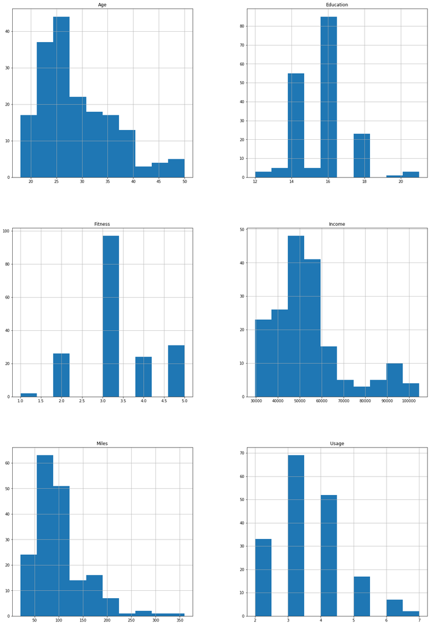

```python
import matplotlib.pyplot as plt
%matplotlib inline

mydata.hist(figsize=(20,30))
```

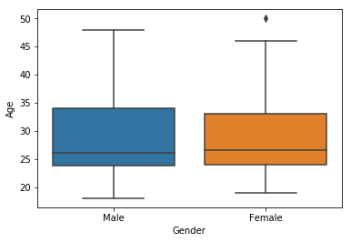

```python
import seaborn as sns

sns.boxplot(x="Gender", y="Age", data=mydata)
```

```python
pd.crosstab(mydata['Product'],mydata['Gender'] )
```

| Gender Product | Female | Male |
| --- | --- | --- |
| TM195 | 40 | 40 |
| TM498 | 29 | 31 |
| TM798 | 7 | 33 |

```python
pd.crosstab(mydata['Product'],mydata['MaritalStatus'] )
```

| MaritalStatus Product | Partnered | Single |
| --- | --- | --- |
| TM195 | 48 | 32 |
| TM498 | 36 | 24 |
| TM798 | 23 | 17 |

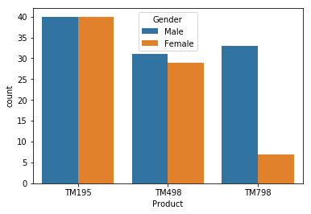

```python
sns.countplot(x="Product", hue="Gender", data=mydata)
```

```python
pd.pivot_table(mydata, index=['Product', 'Gender'],
                     columns=[ 'MaritalStatus'], aggfunc=len)
```

| Product | MaritalStatus Gender | Age Partnered | Age Single | Education Partnered | Education Single | Fitness Partnered | Fitness Single | Income Partnered | Income Single | Miles Partnered | Miles Single | Usage Partnered | Usage Single |
| --- | --- | --- | --- | --- | --- | --- | --- | --- | --- | --- | --- | --- | --- |
| TM195 | Female | 27 | 13 | 27 | 13 | 27 | 13 | 27 | 13 | 27 | 13 | 27 | 13 |
|  | Male | 21 | 19 | 21 | 19 | 21 | 19 | 21 | 19 | 21 | 19 | 21 | 19 |
| TM498 | Female | 15 | 14 | 15 | 14 | 15 | 14 | 15 | 14 | 15 | 14 | 15 | 14 |
|  | Male | 21 | 10 | 21 | 10 | 21 | 10 | 21 | 10 | 21 | 10 | 21 | 10 |
| TM798 | Female | 4 | 3 | 4 | 3 | 4 | 3 | 4 | 3 | 4 | 3 | 4 | 3 |
|  | Male | 19 | 14 | 19 | 14 | 19 | 14 | 19 | 14 | 19 | 14 | 19 | 14 |

```python
pd.pivot_table(mydata,'Income', index=['Product', 'Gender'],
                     columns=[ 'MaritalStatus'])
```

| Product | MaritalStatus Gender | Partnered | Single |
| --- | --- | --- | --- |
| TM195 | Female | 46153.777778 | 45742.384615 |
|  | Male | 50028.000000 | 43265.842105 |
| TM498 | Female | 49724.800000 | 48920.357143 |
|  | Male | 49378.285714 | 47071.800000 |
| TM798 | Female | 84972.250000 | 58516.000000 |
|  | Male | 81431.368421 | 68216.428571 |

```python
pd.pivot_table(mydata,'Miles', index=['Product', 'Gender'],
                     columns=[ 'MaritalStatus'])
```

| Product | MaritalStatus Gender | Partnered | Single |
| --- | --- | --- | --- |
| TM195 | Female | 74.925926 | 78.846154 |
|  | Male | 80.190476 | 99.526316 |
| TM498 | Female | 94.000000 | 80.214286 |
|  | Male | 87.238095 | 91.100000 |
| TM798 | Female | 215.000000 | 133.333333 |
|  | Male | 176.315789 | 147.571429 |

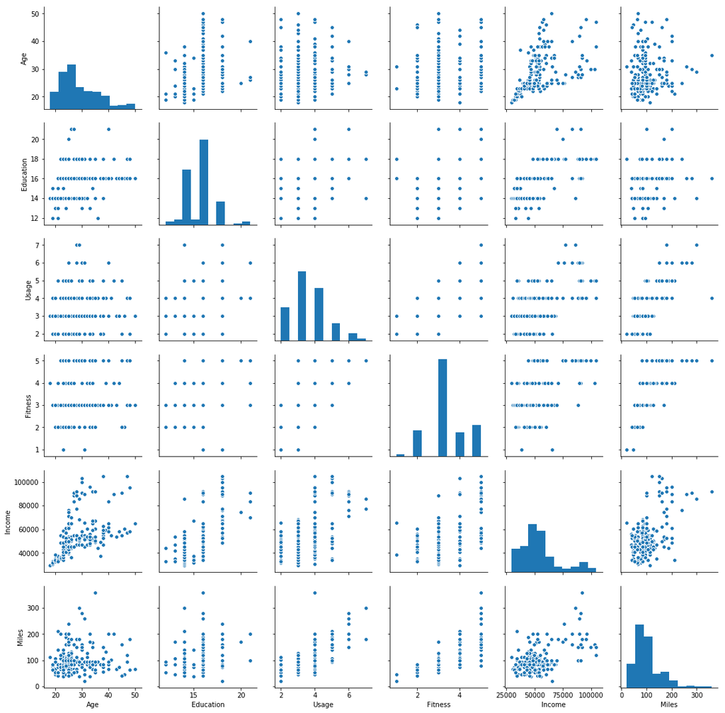

```python
sns.pairplot(mydata)
```

```python
mydata['Age'].std()
```

```
6.9434981353997953
```

```python
mydata['Age'].mean()
```

```
28.788888888888888
```

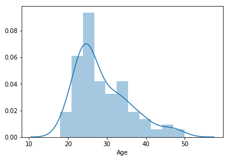

```python
sns.distplot(mydata['Age'])
```

```
array([<matplotlib.axes._subplots.AxesSubplot object at 0x1a1bade860>,
       <matplotlib.axes._subplots.AxesSubplot object at 0x1a1bc68518>], dtype=object)
```

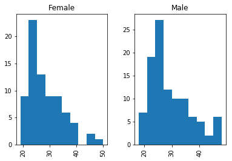

```python
mydata.hist(by='Gender',column = 'Age')
```

```
array([<matplotlib.axes._subplots.AxesSubplot object at 0x1a1bba48d0>,
       <matplotlib.axes._subplots.AxesSubplot object at 0x1a1b9cedd8>], dtype=object)
```

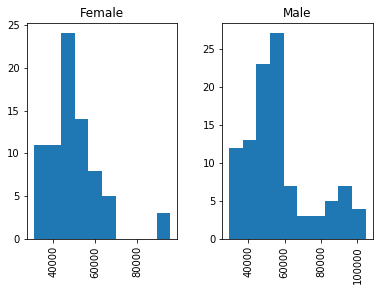

```python
mydata.hist(by='Gender',column = 'Income')
```

```
array([<matplotlib.axes._subplots.AxesSubplot object at 0x1a1a5c3cc0>,
       <matplotlib.axes._subplots.AxesSubplot object at 0x1a19e4b828>], dtype=object)
```

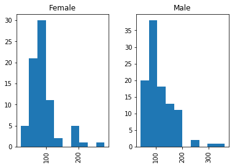

```python
mydata.hist(by='Gender',column = 'Miles')
```

```
array([[<matplotlib.axes._subplots.AxesSubplot object at 0x1a1bfdd668>,
        <matplotlib.axes._subplots.AxesSubplot object at 0x1a1c15e710>]], dtype=object)
```

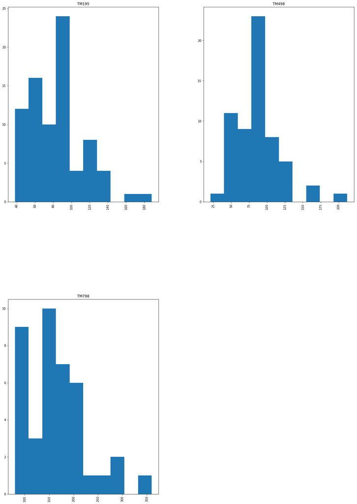

```python
mydata.hist(by='Product',column = 'Miles', figsize=(20,30))
```

```python
corr = mydata.corr()
corr
```

|  | Age | Education | Usage | Fitness | Income | Miles |
| --- | --- | --- | --- | --- | --- | --- |
| Age | 1.000000 | 0.280496 | 0.015064 | 0.061105 | 0.513414 | 0.036618 |
| Education | 0.280496 | 1.000000 | 0.395155 | 0.410581 | 0.625827 | 0.307284 |
| Usage | 0.015064 | 0.395155 | 1.000000 | 0.668606 | 0.519537 | 0.759130 |
| Fitness | 0.061105 | 0.410581 | 0.668606 | 1.000000 | 0.535005 | 0.785702 |
| Income | 0.513414 | 0.625827 | 0.519537 | 0.535005 | 1.000000 | 0.543473 |
| Miles | 0.036618 | 0.307284 | 0.759130 | 0.785702 | 0.543473 | 1.000000 |

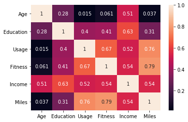

```python
sns.heatmap(corr, annot=True)
```

```python
# Simple Linear Regression


#Load function from sklearn
from sklearn import linear_model

# Create linear regression object
regr = linear_model.LinearRegression()

y = mydata['Miles']
x = mydata[['Usage','Fitness']]

# Train the model using the training sets
regr.fit(x,y)
```

```
LinearRegression(copy_X=True, fit_intercept=True, n_jobs=1, normalize=False)
```

```python
regr.coef_
```

```
array([ 20.21486334,  27.20649954])
```

```python
regr.intercept_
```

```
-56.742881784648617
```

```python
# MilesPredicted = -56.74 + 20.21*Usage + 27.20*Fitness
```